# Advanced command line functions

## DF search functions

The degree of freedom (*df*) is the parameter that controls how closely each individual’s time-trajectory fit eachs data point, balancing the fitting of the raw data and the smoothing of measurements errors. An optimal *df* value ensures that the spline is not overfitted or underfitted on the measurments. The degree of freedom should be established once for a dataset as it is a factor of ‘complexity’ of the time-trajectories under study, but does not change with different variables (same metadata, number of time-points,…)

Refer to santaR theoretical background and Selecting an optimal number of degrees of freedom for more details on *df* and an intuitive approach for its selection.

In order to assist in the selection of an optimal *df* and visualise its impact, the following functions:

- extract the eigen-splines across all time-trajectories of all individuals and all variables
- provide metrics to select the *df* that gives the best fit on the eigen-splines (as a guide value for the whole dataset)

First we extract the eigen-splines across the whole dataset using `get_eigen_spline()`:

```r
var_eigen  <- get_eigen_spline( inputData=acuteInflammation$data, ind=acuteInflammation$meta$ind, time=acuteInflammation$meta$time)
```

```
## nipals calculated PCA
## Importance of component(s):
##                  PC1    PC2     PC3     PC4     PC5      PC6
## R2            0.8281 0.0679 0.05191 0.02942 0.01436 0.008339
## Cumulative R2 0.8281 0.8960 0.94788 0.97731 0.99166 1.000000
```

```
## total time: 0.5 secs
```

```r
# The projection of each eigen-spline at each time-point:
var_eigen$matrix
```

|  | 0 | 4 | 8 | 12 | 24 | 48 | 72 |
| --- | --- | --- | --- | --- | --- | --- | --- |
| **PC1** | 5.933 | -24 | -2.723 | 2.045 | 6.146 | 6.049 | 6.546 |
| **PC2** | -4.34 | 0.5412 | -2.18 | 1.551 | -0.1612 | -1.158 | 5.746 |
| **PC3** | -3.195 | -1.782 | 5.305 | 1.726 | -0.1319 | -1.014 | -0.9077 |
| **PC4** | 0.4109 | -0.09695 | -1.724 | 4.28 | 0.1921 | -1.313 | -1.749 |
| **PC5** | -1.198 | 0.2399 | -0.5312 | -0.636 | 3.136 | -0.1187 | -0.8928 |
| **PC6** | 1.094 | -0.07218 | 0.4487 | -0.3782 | 0.5242 | -2.278 | 0.6614 |

```r
# The variance explained by each eigen-spline
var_eigen$variance
```

```
## [1] 0.828073142 0.067899396 0.051910368 0.029422712 0.014355448 0.008338933
```

```r
# PCA summary
summary(var_eigen$model)
```

```
## nipals calculated PCA
## Importance of component(s):
##                  PC1    PC2     PC3     PC4     PC5      PC6
## R2            0.8281 0.0679 0.05191 0.02942 0.01436 0.008339
## Cumulative R2 0.8281 0.8960 0.94788 0.97731 0.99166 1.000000
```

It is then possible to estimate the *df* corresponding to the minimisation of a metric (penalised_residuals cross-validated, penalised_residuals general cross-validation, AIC, BIC or AICc) using `get_eigen_DF()`. The best *df* can either be averaged over all eigen-splines `df` or weighted by the variance explained by each eigen-spline `wdf`:

```r
# The projection of each eigen-spline at each time-point:
get_eigen_DF(var_eigen)

# $df
```

| CV | GCV | AIC | BIC | AICc |
| --- | --- | --- | --- | --- |
| 2.712 | 3.298 | 6.289 | 6.298 | 3.499 |

```r
# $wdf
```

| CV | GCV | AIC | BIC | AICc |
| --- | --- | --- | --- | --- |
| 2.181 | 2.095 | 6.943 | 6.944 | 5.55 |

The evolution of these metrics (*y*) depending on *df* (*x*) can be plotted for each eigen-spline using `get_param_evolution()` and `plot_param_evolution()`:

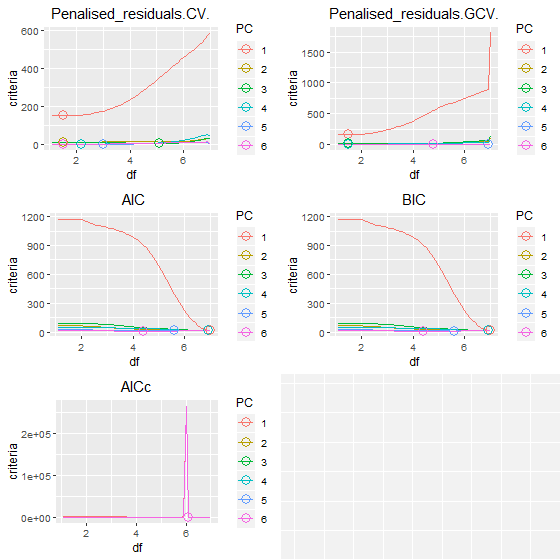

```r
library(gridExtra)

# generate all the parameter values across df
var_eigen_paramEvo  <- get_param_evolution(var_eigen, step=0.1)

# plot the metric evolution
plot(arrangeGrob(grobs=plot_param_evolution(var_eigen_paramEvo, scaled=FALSE)))
```

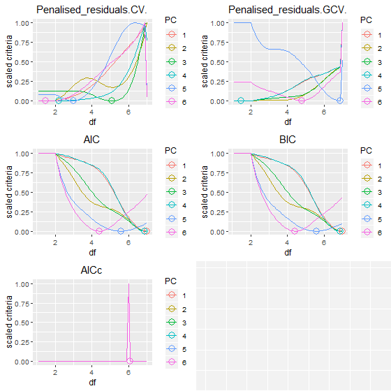

```r
# Scale the metrics for each eigen-spline between 0 and 1
plot(arrangeGrob(grobs=plot_param_evolution(var_eigen_paramEvo, scaled=TRUE)))
```

As we can see, the recommended *df* can vary widely depending on the metric selected. `get_eigen_DFoverlay_list()` will plot all eigen-projections (green points), a manually selected *df* (blue line) and automatically fitted *df* (red line), while grey lines represent splines at 0.2 *df* intervals (default value):

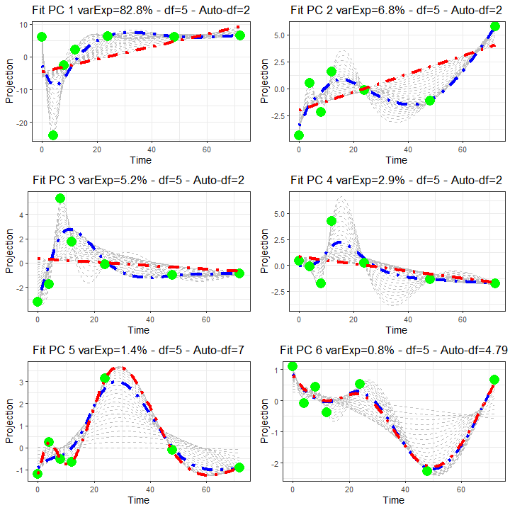

```r
library(gridExtra)

# plot all eigen-projections
plot(arrangeGrob(grobs=get_eigen_DFoverlay_list(var_eigen, manualDf = 5)))
```

It should be noted that *df=2* corresponds to a linear model. *df=number(time-points)* corresponds to a curve that will go through all points (overfitted).

A final factor to take into account is the number of points needed for each individuals depending on the *df* selected:

- the minimum number of time-points needed is the *df*
- if for example *df=10*, all individuals that have less than 10 time-points have to be rejected

Using `plot_nbTP_histogram()` we can visualise how many samples would have to be rejected for a given *df*. Due to the lack of missing values in the `acuteInflammation` dataset, the plots is not very informative.

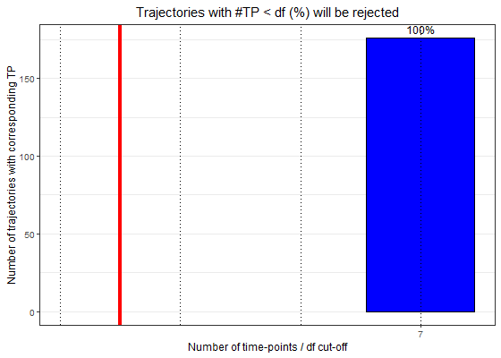

```r
# dfCutOff controls which cut-off is to be applied
plot_nbTP_histogram(var_eigen, dfCutOff=5)
```

As it does not seem to be possible to automatically select the degree of freedom, a choice based on visualisation of the splines while being careful of overfitting, keeping in mind the ‘expected’ evolution of the underlying process is the most sensible approach.

## Fitting, Confidence bands and plotting

Fitting of each individual and group mean curves are achieved with `santaR_fit()` to generate a `SANTAObj` that is then used for processing:

```r
var1 <- santaR_fit(var1_input, df=5, groupin=var1_group)

# it is possible to access the SANTAObj structure, which will be filled in the following steps
var1$properties
```

```
## $df
## [1] 5
##
## $CBand
## $CBand$status
## [1] FALSE
##
## $CBand$nBoot
## [1] NA
##
## $CBand$alpha
## [1] NA
##
##
## $pval.dist
## $pval.dist$status
## [1] FALSE
##
## $pval.dist$nPerm
## [1] NA
##
## $pval.dist$alpha
## [1] NA
##
##
## $pval.fit
## $pval.fit$status
## [1] FALSE
##
## $pval.fit$nPerm
## [1] NA
##
## $pval.fit$alpha
## [1] NA
```

```r
var1$general
```

```
## $inputData
##                0           4           8          12          24
## ind_1 -0.2178789  0.91102691  0.58499815  1.62075258  0.78381065
## ind_2 -0.2178789  4.19746095 -0.08218860 -0.02869199 -1.03962428
## ind_3 -0.5115942 -0.01893874 -0.29144117  0.40496659 -0.19688610
## ind_4 -0.5115942  0.08296167 -0.73976352 -1.03962428 -1.03962428
## ind_5 -0.3968660  0.03205536 -0.04776568  0.43082440  0.02465099
## ind_6 -0.3968660  1.36463826 -0.52139013 -0.76250288 -1.03962428
## ind_7 -0.3639912  0.45089171  0.32184021  0.87155065  0.33945976
## ind_8 -0.3639912  1.85844915 -0.41087558 -0.48644857 -1.03962428
##               48          72
## ind_1  0.4986962  2.34452908
## ind_2 -0.7635814 -0.85939701
## ind_3 -0.2911434 -0.07503976
## ind_4 -1.0396243 -1.03962428
## ind_5  0.0574394  0.58606071
## ind_6 -1.0396243 -1.03962428
## ind_7  0.3697976  1.85572115
## ind_8 -1.0396243 -1.03962428
##
## $grouping
##     ind  group
## 1 ind_1 Group1
## 2 ind_2 Group2
## 3 ind_3 Group1
## 4 ind_4 Group2
## 5 ind_5 Group1
## 6 ind_6 Group2
## 7 ind_7 Group1
## 8 ind_8 Group2
##
## $cleanData.in
##                0           4           8          12          24
## ind_1 -0.2178789  0.91102691  0.58499815  1.62075258  0.78381065
## ind_3 -0.5115942 -0.01893874 -0.29144117  0.40496659 -0.19688610
## ind_5 -0.3968660  0.03205536 -0.04776568  0.43082440  0.02465099
## ind_7 -0.3639912  0.45089171  0.32184021  0.87155065  0.33945976
## ind_2 -0.2178789  4.19746095 -0.08218860 -0.02869199 -1.03962428
## ind_4 -0.5115942  0.08296167 -0.73976352 -1.03962428 -1.03962428
## ind_6 -0.3968660  1.36463826 -0.52139013 -0.76250288 -1.03962428
```

[output cut: 45 more lines]

```
##
## $pval.fit.l
## [1] NA
##
## $pval.fit.u
## [1] NA
##
## $meanCurve
## Call:
## stats::smooth.spline(x = time[notNA], y = meanVal[notNA], df = sum(notNA))
##
## Smoothing Parameter  spar= -0.7565504  lambda= 6.486837e-13 (21 iterations)
## Equivalent Degrees of Freedom (Df): 7
## Penalized Criterion (RSS): 2.358641e-17
## GCV: 0.03087262
```

```r
var1$groups$Group1
```

```
## $rejectedInd
## list()
##
## $curveInd
## $curveInd$ind_1
## Call:
## stats::smooth.spline(x = xInd, y = yInd, df = df)
##
## Smoothing Parameter  spar= 0.3926483  lambda= 0.0001303627 (10 iterations)
## Equivalent Degrees of Freedom (Df): 4.999723
## Penalized Criterion (RSS): 0.4388556
## GCV: 0.7677847
##
## $curveInd$ind_3
## Call:
## stats::smooth.spline(x = xInd, y = yInd, df = df)
##
## Smoothing Parameter  spar= 0.3926483  lambda= 0.0001303627 (10 iterations)
## Equivalent Degrees of Freedom (Df): 4.999723
## Penalized Criterion (RSS): 0.1867747
## GCV: 0.3267653
##
## $curveInd$ind_5
## Call:
## stats::smooth.spline(x = xInd, y = yInd, df = df)
##
## Smoothing Parameter  spar= 0.3926483  lambda= 0.0001303627 (10 iterations)
## Equivalent Degrees of Freedom (Df): 4.999723
## Penalized Criterion (RSS): 0.07529958
## GCV: 0.1317378
##
## $curveInd$ind_7
## Call:
## stats::smooth.spline(x = xInd, y = yInd, df = df)
##
## Smoothing Parameter  spar= 0.3926483  lambda= 0.0001303627 (10 iterations)
## Equivalent Degrees of Freedom (Df): 4.999723
## Penalized Criterion (RSS): 0.1480858
## GCV: 0.2590785
##
```

[output cut: 80 more lines]

```
## ind_3 -0.07503976
## ind_5  0.58606071
## ind_7  1.85572115
##
## $groupData.pred
##                 0           4           8        12          24         48
## ind_1 -0.03040631  0.56124885  0.98284290 1.2842945  0.88191298  0.5113377
## ind_3 -0.43772801 -0.19221430 -0.00594887 0.1514541 -0.12285555 -0.2973872
## ind_5 -0.33467888 -0.08003787  0.11733113 0.2624271  0.08162091  0.0552708
## ind_7 -0.21917438  0.21856919  0.51666059 0.6967476  0.40689485  0.3762108
##                72
## ind_1  2.33470416
## ind_3 -0.07539689
## ind_5  0.58446600
## ind_7  1.84936123
```

Confidence bands on the group mean curves can be calculated by bootstrapping using `santaR_CBand()`:

```r
var1 <- santaR_CBand(var1)
```

Plot is achieved using `santaR_plot()`, for more details see Plotting options:

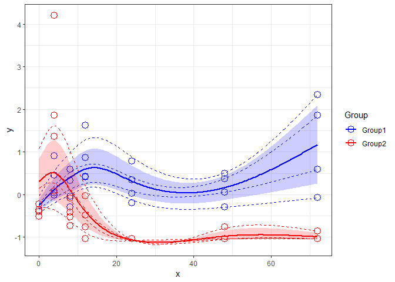

```r
santaR_plot(var1)
```

## P-values calculation

The *p*-values are calculated by the comparison of distance between group mean curves by random sampling of individuals. Due to the stochastic nature of the test, the *p*-value obtained can slighlty vary depending on the random draw. This can be compounded by using the lower and upper confidence range on the *p*-value that is estimated at the same time.

`santaR_pvalue_dist()` will calculate the significance of the difference between two groups:

```r
var1 <- santaR_pvalue_dist(var1)
# p-value
var1$general$pval.dist
```

```
## [1] 0.007992008
```

```r
# lower p-value confidence range
var1$general$pval.dist.l
```

```
## [1] 0.004053809
```

```r
# upper p-value confidence range
var1$general$pval.dist.u
```

```
## [1] 0.0156958
```

```r
# curve correlation coefficiant
var1$general$pval.curveCorr
```

```
## [1] -0.1309867
```

## See Also

- Getting Started with santaR
- How to prepare input data for santaR
- santaR theoretical background
- Graphical user interface use
- Automated command line analysis
- Plotting options
- Selecting an optimal number of degrees of freedom